# In-Class Exercise

Ali Altintas

23/11/2020

```r
library(scales)
library(grid)
library(tidyverse)
library(lubridate)
library(stringr)
library(ggplot2)
library(naniar)
library(readxl)
library(reshape2)
library(ggthemes)
```

## Preprocessing

```r
df<-read_xlsx(file.choose(),n_max = 130)

df$Tarih<-paste0(df$Tarih,as.character("-01"))

df$Tarih<-as.Date(df$Tarih, format="%Y-%m-%d")

df<-rename(df,Tarih=Tarih,
             Sifir_ikinciEl_Satilan_Konut=`TP AKONUTSAT1 T40`,
             Ipotekli_Satilan_Konut= `TP AKONUTSAT2 T40`,
             Sifir_Satilan_Konut=`TP AKONUTSAT3 T40`,
             Ikinci_El_Satilan_Konut=`TP AKONUTSAT4 T40`,
             Yabanciya_Satilan_Konut=`TP DISKONSAT ISTANBUL`,
             YeniKonut_Fiyat_Endeks=`TP HEDONIKYKFE IST`,
             Istanbul_TR10=`TP HKFE02`,
             M2_Fiyati=`TP TCBF02 ISTANBUL`)
```

## Explanation Of Each Column

Tarih: Date Column

Sifir_ikinciEl_Satilan_Konut: Pre-owned Housing + New Housing total sold quantity in Istanbul Ipotekli_Satilan_Konut : Servient Houising sold quantity in Istanbul Sifir_Satilan_Konut : New Housing sold quantity in Istanbul Ikinci_El_Satilan_Konut : Pre-Owned Housing sold quantity in Istanbul Yabanciya_Satilan_Konut : Housing Sold Quantity to non-Turkish Citizen in Istanbul YeniKonut_Fiyat_Endeks : New Housing Price Index in Istanbul Istanbul_TR10 : Istanbul TR10 region housing price index in Istanbul M2_Fiyati : Square metre price in Istanbul

```r
str(df)
```

```
## tibble [129 x 9] (S3: tbl_df/tbl/data.frame)
##  $ Tarih                       : Date[1:129], format: "2010-01-01" "2010-02-01" ...
##  $ Sifir_ikinciEl_Satilan_Konut: num [1:129] NA NA NA NA NA NA NA NA NA NA ...
##  $ Ipotekli_Satilan_Konut      : num [1:129] NA NA NA NA NA NA NA NA NA NA ...
##  $ Sifir_Satilan_Konut         : num [1:129] NA NA NA NA NA NA NA NA NA NA ...
##  $ Ikinci_El_Satilan_Konut     : num [1:129] NA NA NA NA NA NA NA NA NA NA ...
##  $ Yabanciya_Satilan_Konut     : num [1:129] NA NA NA NA NA NA NA NA NA NA ...
##  $ YeniKonut_Fiyat_Endeks      : num [1:129] 35.9 36.6 37.4 38 38 37.6 37.3 38.1 38.8 39.1 ...
##  $ Istanbul_TR10               : num [1:129] 36 36.2 36.5 36.9 37.1 37 37.2 37.3 37.7 38.1 ...
##  $ M2_Fiyati                   : num [1:129] 1415 1420 1428 1443 1449 ...
```

## Missing Datas

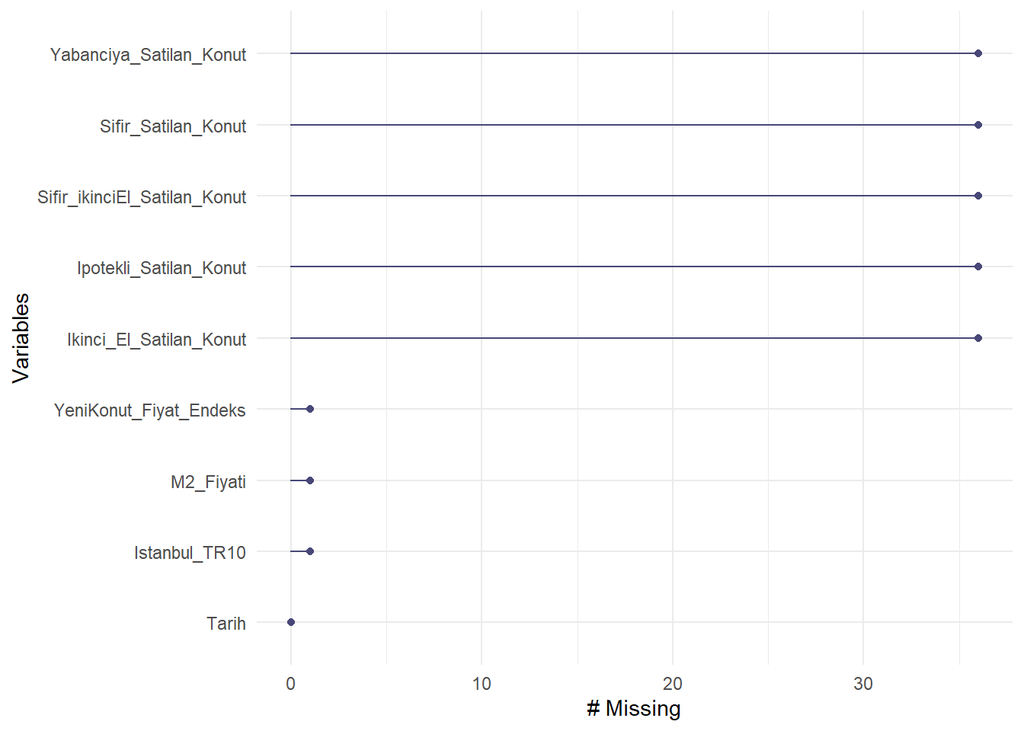

```r
gg_miss_var(df)
```